# IMDB Project

## Setup

The goal of this project is to research which variables possibly influence the total revenue streams that a released movie generates by performing a multiple regression. For this purpose, data belonging to around 5000 movies from the Internet Movie Database (IMDB) has been used. This data has been retrieved from [Kaggle](https://www.kaggle.com/carolzhangdc/imdb-5000-movie-dataset).

This project is of a more exploratory nature, which means that we are looking for possible connections. As such, it does not contain a strong justification for the included variables and for the analysis methods. Interpret the findings with this information in mind.

First, let's look at the available data. We start by importing the required modules and by reading the csv file.

```python
import numpy as np
import pandas as pd
movies = pd.read_csv("movie_metadata.csv")
```

Let's look at the columns included in this dataset, including the total count of non-missing values in that colum:

```python
movies.info()
```

```
<class 'pandas.core.frame.DataFrame'>
RangeIndex: 5043 entries, 0 to 5042
Data columns (total 28 columns):
 #   Column                     Non-Null Count  Dtype
---  ------                     --------------  -----
 0   color                      5024 non-null   object
 1   director_name              4939 non-null   object
 2   num_critic_for_reviews     4993 non-null   float64
 3   duration                   5028 non-null   float64
 4   director_facebook_likes    4939 non-null   float64
 5   actor_3_facebook_likes     5020 non-null   float64
 6   actor_2_name               5030 non-null   object
 7   actor_1_facebook_likes     5036 non-null   float64
 8   gross                      4159 non-null   float64
 9   genres                     5043 non-null   object
```

[output cut: 20 more lines]

These columns correspond to the variables that we could use for our analysis. Some of these variables will correlate with the total revenue that movies generate and others will not. In this project, potentially relevant or interesting variables will be handpicked. The variables that we choose will need a plausible connection to total revenue, as well as a sufficient degree of measurability. This means that variables of a categorical or nominal nature (e.g. 'yes/no', 'A/B/C', '0/1') will be excluded.

The result of this handpicking is as follows:

**Dependent variable:**

- gross (total revenue stream generated by movie in USD)

**Independent variables:**

- duration (total runtime of the movie in minutes)
- budget (total budget of the movie in US dollars)
- num_critic_for_reviews (number of reviews by critics)
- director_facebook_likes (total number of movie director Facebook likes)
- cast_total_facebook_likes (total number of Facebook likes of the entire cast)

As you can see, all of these independent variables are of a numerical nature, meaning they can be measured. Also, all of them, except num_critic_for_reviews, exist before the release of the movie in question. Other variables, like imdb_score (IMDB score), num_voted_users (total number of IMDB users that voted) and movie_facebook_likes (total amount of Facebook likes for the movie) exist as a result of the movie's release. Because the total revenue is an indicator of the popularity of a movie, it is plausible that the dependent variable gross could have an effect on these variables, creating a kind of feedback loop. We want to make sure that our independent variables remain independent, which is why variables such as these have been excluded.

## Data cleaning

In this section, we "wrangle" the data into a shape that is suitable for the analysis. This section contains filtering by country, variable selection, missing value, duplicate row and outlier removal and data type correction. After every action that modifies the dataset, the following line of code will be used to display up to date information about the data:

```
movies.info()
```

### Filtering by country

We want the gross and budget variables to be in US dollars. Currently, (a number of) movies that are produced outside the USA have their values in the gross and budget variables expressed in a local currency. Currency conversion rates being what they are, this can quickly lead to wildly inaccurate analysis results, which is why we filter out all movies that are produced outside the US:

```python
movies = movies[movies.country == "USA"]
movies.info()
```

```
<class 'pandas.core.frame.DataFrame'>
Int64Index: 3807 entries, 0 to 5042
Data columns (total 28 columns):
 #   Column                     Non-Null Count  Dtype
---  ------                     --------------  -----
 0   color                      3793 non-null   object
 1   director_name              3733 non-null   object
 2   num_critic_for_reviews     3768 non-null   float64
 3   duration                   3801 non-null   float64
 4   director_facebook_likes    3733 non-null   float64
 5   actor_3_facebook_likes     3794 non-null   float64
 6   actor_2_name               3800 non-null   object
 7   actor_1_facebook_likes     3803 non-null   float64
 8   gross                      3235 non-null   float64
 9   genres                     3807 non-null   object
```

[output cut: 20 more lines]

### Variable selection

Let's modify the dataset to only contain the columns chosen for the analysis:

```python
movies = movies[["movie_title", "gross", "duration", "budget", "num_critic_for_reviews",
                 "director_facebook_likes", "cast_total_facebook_likes"]]
movies.info()
```

```
<class 'pandas.core.frame.DataFrame'>
Int64Index: 3807 entries, 0 to 5042
Data columns (total 7 columns):
 #   Column                     Non-Null Count  Dtype
---  ------                     --------------  -----
 0   movie_title                3807 non-null   object
 1   gross                      3235 non-null   float64
 2   duration                   3801 non-null   float64
 3   budget                     3509 non-null   float64
 4   num_critic_for_reviews     3768 non-null   float64
 5   director_facebook_likes    3733 non-null   float64
 6   cast_total_facebook_likes  3807 non-null   int64
dtypes: float64(5), int64(1), object(1)
memory usage: 237.9+ KB
```

### Missing values

```python
movies = movies.dropna()
movies.info()
```

```
<class 'pandas.core.frame.DataFrame'>
Int64Index: 3073 entries, 0 to 5042
Data columns (total 7 columns):
 #   Column                     Non-Null Count  Dtype
---  ------                     --------------  -----
 0   movie_title                3073 non-null   object
 1   gross                      3073 non-null   float64
 2   duration                   3073 non-null   float64
 3   budget                     3073 non-null   float64
 4   num_critic_for_reviews     3073 non-null   float64
 5   director_facebook_likes    3073 non-null   float64
 6   cast_total_facebook_likes  3073 non-null   int64
dtypes: float64(5), int64(1), object(1)
memory usage: 192.1+ KB
```

As you can see, after cleaning we are left with a dataset containing 3073 rows. We can be confident that none of these rows contain any missing values.

### Duplicate removal

Duplicates are exactly matching rows that appear multiple times in the dataset. Too many duplicates will skew the analysis results. Luckily, these are easily removed:

```python
movies = movies.drop_duplicates()
movies.info()
```

```
<class 'pandas.core.frame.DataFrame'>
Int64Index: 3006 entries, 0 to 5042
Data columns (total 7 columns):
 #   Column                     Non-Null Count  Dtype
---  ------                     --------------  -----
 0   movie_title                3006 non-null   object
 1   gross                      3006 non-null   float64
 2   duration                   3006 non-null   float64
 3   budget                     3006 non-null   float64
 4   num_critic_for_reviews     3006 non-null   float64
 5   director_facebook_likes    3006 non-null   float64
 6   cast_total_facebook_likes  3006 non-null   int64
dtypes: float64(5), int64(1), object(1)
memory usage: 187.9+ KB
```

The number of rows has gone down from 3073 to 3006, meaning that 67 duplicate rows have been removed.

### Data type

To increase the readability of the data, we need to look at data types next. All of the columns containing numerical values actually only consist integers. This can easily confirmed:

```python
for col in movies.columns[1:]:
    print(col + " is integer: ", end="")
    print((movies[col] % 1  == 0).all())
```

```
gross is integer: True
duration is integer: True
budget is integer: True
num_critic_for_reviews is integer: True
director_facebook_likes is integer: True
cast_total_facebook_likes is integer: True
```

After confirming that we are dealing with integers, the column data types can be recast to match the values:

```python
for col in movies.columns[1:6]:
    movies[col] = movies[col].astype("int64")

movies.info()
```

```
<class 'pandas.core.frame.DataFrame'>
Int64Index: 3006 entries, 0 to 5042
Data columns (total 7 columns):
 #   Column                     Non-Null Count  Dtype
---  ------                     --------------  -----
 0   movie_title                3006 non-null   object
 1   gross                      3006 non-null   int64
 2   duration                   3006 non-null   int64
 3   budget                     3006 non-null   int64
 4   num_critic_for_reviews     3006 non-null   int64
 5   director_facebook_likes    3006 non-null   int64
 6   cast_total_facebook_likes  3006 non-null   int64
dtypes: int64(6), object(1)
memory usage: 187.9+ KB
```

### Outliers

The move industry is a competitive business and as such may be subject to something similar to the [Pareto distribution](https://en.wikipedia.org/wiki/Pareto_distribution). Some movies may see exceptionally high values in certain variables. These high values are then outliers that may skew the analysis results. Outliers must be detected and removed.

A good way to understand data is to visually represent it. The histograms below show how the variables in the dataset are distributed. The height of the bars represents the count of movies in a certain bin of the histogram.

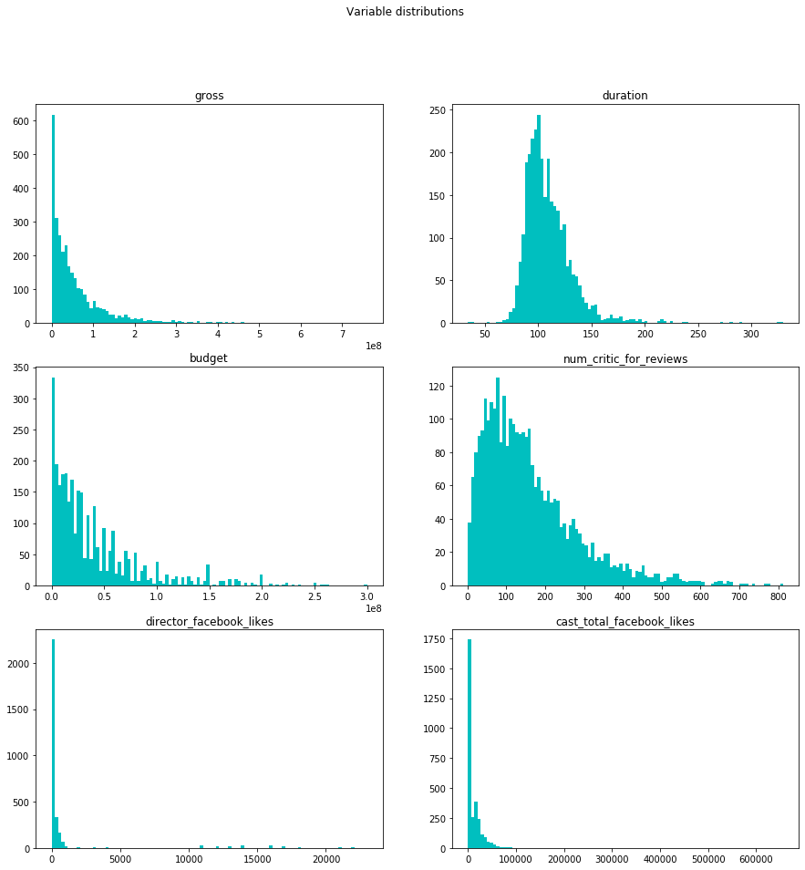

```python
import matplotlib.pyplot as plt
fig, axs = plt.subplots(3, 2,figsize=(15,15))
fig.suptitle("Variable distributions")

axs[0,0].hist(movies.gross, color="c", bins=100);
axs[0,0].set_title("gross")

axs[0,1].hist(movies.duration, color="c", bins=100);
axs[0,1].set_title("duration")

axs[1,0].hist(movies.budget, color="c", bins=100);
axs[1,0].set_title("budget")

axs[1,1].hist(movies.num_critic_for_reviews, color="c", bins=100);
axs[1,1].set_title("num_critic_for_reviews")

axs[2,0].hist(movies.director_facebook_likes, color="c", bins=100);
axs[2,0].set_title("director_facebook_likes")

axs[2,1].hist(movies.cast_total_facebook_likes, color="c", bins=100);
axs[2,1].set_title("cast_total_facebook_likes")
```

The risk exists that these outliers will skew the results of the final analysis. Because of this, a new version of the dataset will be created where the most extreme outliers have been removed. We do this by calculating the z-score of every value for every variable. Values with a z-score of 3 and higher will be removed from the dataset.

```python
from scipy import stats

z = np.abs(stats.zscore(movies.drop(["movie_title"], axis=1)))
movies = movies[(z < 3).all(axis=1)]

movies.info()
```

```
<class 'pandas.core.frame.DataFrame'>
Int64Index: 2670 entries, 59 to 5042
Data columns (total 7 columns):
 #   Column                     Non-Null Count  Dtype
---  ------                     --------------  -----
 0   movie_title                2670 non-null   object
 1   gross                      2670 non-null   int64
 2   duration                   2670 non-null   int64
 3   budget                     2670 non-null   int64
 4   num_critic_for_reviews     2670 non-null   int64
 5   director_facebook_likes    2670 non-null   int64
 6   cast_total_facebook_likes  2670 non-null   int64
dtypes: int64(6), object(1)
memory usage: 166.9+ KB
```

As you can see, we are left with 2670 rows. Now let's take a look at the histograms from earlier, but with outliers removed:

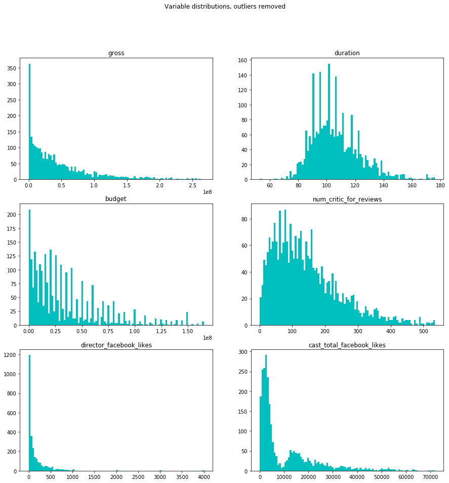

```python
fig, axs = plt.subplots(3, 2,figsize=(15,15))
fig.suptitle("Variable distributions, outliers removed")

axs[0,0].hist(movies.gross, color="c", bins=100);
axs[0,0].set_title("gross")

axs[0,1].hist(movies.duration, color="c", bins=100);
axs[0,1].set_title("duration")

axs[1,0].hist(movies.budget, color="c", bins=100);
axs[1,0].set_title("budget")

axs[1,1].hist(movies.num_critic_for_reviews, color="c", bins=100);
axs[1,1].set_title("num_critic_for_reviews")

axs[2,0].hist(movies.director_facebook_likes, color="c", bins=100);
axs[2,0].set_title("director_facebook_likes")

axs[2,1].hist(movies.cast_total_facebook_likes, color="c", bins=100);
axs[2,1].set_title("cast_total_facebook_likes")
```

The overall shape of the histograms is similar to before, but removing the more extreme outliers has improved the visibility and will lead to more accurate analysis results.

Our dataset is now prepared for analysis. To get an impression of what the final dataset looks like, here is a display of the 15 highest grossing movies in the dataset.

```python
movies.sort_values(by="gross", ascending=False).head(15)
```

|  | movie_title | gross | duration | budget | num_critic_for_reviews | director_facebook_likes | cast_total_facebook_likes |
| --- | --- | --- | --- | --- | --- | --- | --- |
| 927 | Shrek | 267652016 | 90 | 60000000 | 212 | 80 | 275 |
| 349 | The Incredibles | 261437578 | 115 | 92000000 | 283 | 663 | 1901 |
| 218 | How the Grinch Stole Christmas | 260031035 | 110 | 123000000 | 175 | 2000 | 4146 |
| 117 | I Am Legend | 256386216 | 104 | 150000000 | 323 | 508 | 13076 |
| 1403 | The Blind Side | 255950375 | 129 | 29000000 | 261 | 102 | 3389 |
| 440 | The Hangover Part II | 254455986 | 102 | 80000000 | 383 | 480 | 16143 |
| 633 | Despicable Me | 251501645 | 87 | 69000000 | 304 | 275 | 11608 |
| 250 | Night at the Museum | 250863268 | 108 | 110000000 | 179 | 189 | 55486 |
| 352 | Men in Black | 250147615 | 98 | 90000000 | 175 | 188 | 12998 |
| 353 | Toy Story 2 | 245823397 | 82 | 90000000 | 191 | 487 | 21275 |
| 583 | Cars | 244052771 | 117 | 120000000 | 256 | 487 | 4905 |
| 436 | Bruce Almighty | 242589580 | 101 | 81000000 | 191 | 293 | 21276 |
| 394 | Twister | 241688385 | 113 | 92000000 | 114 | 101 | 26239 |
| 3737 | My Big Fat Greek Wedding | 241437427 | 95 | 5000000 | 168 | 38 | 1495 |
| 87 | Shrek Forever After | 238371987 | 93 | 165000000 | 226 | 31 | 4628 |

## Analysis

**Descriptive analysis**

Before running the numbers, descriptive and visual statistics will be shown. This helps the reader to get an understanding of the data. This next table displays the most commonly used descriptive statistics of the variables in the dataset (rounded for readability). These statistics are the mean, standard deviation, minimum and maximum values and the lower quartile, median and upper quartile.

```python
movies.describe().round(decimals=2)
```

|  | gross | duration | budget | num_critic_for_reviews | director_facebook_likes | cast_total_facebook_likes |
| --- | --- | --- | --- | --- | --- | --- |
| count | 2.670000e+03 | 2670.00 | 2.670000e+03 | 2670.00 | 2670.00 | 2670.00 |
| mean | 4.571577e+07 | 106.13 | 3.363351e+07 | 144.42 | 152.32 | 10126.66 |
| std | 4.910191e+07 | 16.67 | 3.310796e+07 | 102.09 | 285.75 | 12184.44 |
| min | 7.030000e+02 | 53.00 | 2.180000e+02 | 1.00 | 0.00 | 0.00 |
| 25% | 9.695968e+06 | 94.00 | 9.525000e+06 | 66.00 | 10.00 | 2055.25 |
| 50% | 3.051875e+07 | 104.00 | 2.400000e+07 | 123.00 | 52.00 | 3986.00 |
| 75% | 6.459686e+07 | 116.00 | 4.875000e+07 | 197.75 | 179.00 | 15270.50 |
| max | 2.676520e+08 | 176.00 | 1.650000e+08 | 535.00 | 4000.00 | 71973.00 |

**Visual analysis**

Scatter plots are a useful tool for visualizing the relationship between variables. In this case, the scatter plots display the relationship between each variable in the dataset and the dependent variable gross. The first scatter plot (top left) can be ignored.

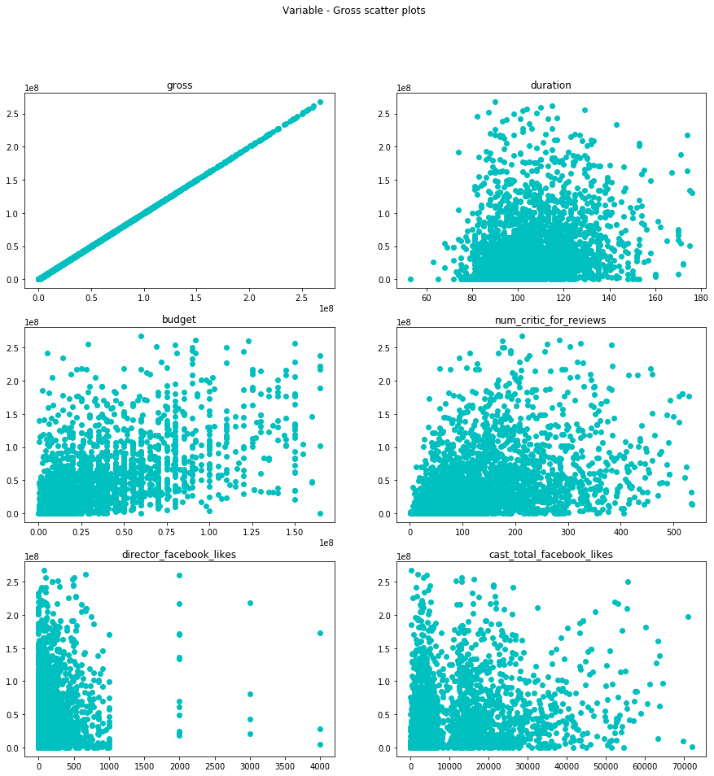

```python
import matplotlib.pyplot as plt
fig, axs = plt.subplots(3, 2,figsize=(15,15))
fig.suptitle("Variable - Gross scatter plots")

axs[0,0].scatter(movies.gross, movies.gross, color="c");
axs[0,0].set_title("gross")

axs[0,1].scatter(movies.duration, movies.gross, color="c");
axs[0,1].set_title("duration")

axs[1,0].scatter(movies.budget, movies.gross, color="c");
axs[1,0].set_title("budget")

axs[1,1].scatter(movies.num_critic_for_reviews, movies.gross, color="c");
axs[1,1].set_title("num_critic_for_reviews")

axs[2,0].scatter(movies.director_facebook_likes, movies.gross, color="c");
axs[2,0].set_title("director_facebook_likes")

axs[2,1].scatter(movies.cast_total_facebook_likes, movies.gross, color="c");
axs[2,1].set_title("cast_total_facebook_likes")
```

**Multicollinearity testing**

Multicollinearity is a term for a situation where multiple independent variables in a statistical model not only influence the dependent variable, but also each other. Too much multicollinearity will lead to unreliable analysis results.

We can test for multicollinearity by calculate the Variance Inflation Factor (VIF) for each independent variable. VIF values under 3 are ideal, VIF values over 5 indicate some multicollinearity and VIF values over 10 indicate severely problematic levels of multicollinearity.

```python
from statsmodels.stats.outliers_influence import variance_inflation_factor

vif_vars = movies.reindex(columns=['duration','budget', 'num_critic_for_reviews',
                                  'director_facebook_likes', 'cast_total_facebook_likes'])

vif = pd.DataFrame()
vif["VIF"] = [variance_inflation_factor(vif_vars.values, i) for i in range(vif_vars.shape[1])]
print(vif.set_index(vif_vars.columns).round(2))
```

```
                            VIF
duration                   3.86
budget                     2.43
num_critic_for_reviews     3.66
director_facebook_likes    1.35
cast_total_facebook_likes  1.91
```

The calculated VIF values are small enough that we can reliably proceed with the statistical analysis; no variable needs to be removed.

**Statistical analysis**

In this section we find out whether the data can be used to find statistically significant results, and if so, what these results are and how they fit the insights derived from the scatter plots.

We make use of multiple linear regression for the statistical analysis. First, we import the necessary libraries, after which we create, fit and view the results of a statistical model.

```python
import statsmodels.formula.api as smf

model = smf.ols('gross ~ duration + budget + num_critic_for_reviews +\
                director_facebook_likes + cast_total_facebook_likes',
                data=movies)
results = model.fit()
results.summary()
```

OLS Regression Results

| Dep. Variable: | gross | R-squared: | 0.371 |
| --- | --- | --- | --- |
| Model: | OLS | Adj. R-squared: | 0.370 |
| Method: | Least Squares | F-statistic: | 314.7 |
| Date: | Tue, 15 Dec 2020 | Prob (F-statistic): | 2.61e-265 |
| Time: | 12:10:14 | Log-Likelihood: | -50453. |
| No. Observations: | 2670 | AIC: | 1.009e+05 |
| Df Residuals: | 2664 | BIC: | 1.010e+05 |
| Df Model: | 5 |  |  |
| Covariance Type: | nonrobust |  |  |

|  | coef | std err | t | P>\|t\| | [0.025 | 0.975] |
| --- | --- | --- | --- | --- | --- | --- |
| Intercept | -7.241e+06 | 4.91e+06 | -1.473 | 0.141 | -1.69e+07 | 2.4e+06 |
| duration | 1.394e+05 | 4.8e+04 | 2.904 | 0.004 | 4.52e+04 | 2.33e+05 |
| budget | 0.7476 | 0.025 | 29.929 | 0.000 | 0.699 | 0.797 |
| num_critic_for_reviews | 7.348e+04 | 8164.494 | 9.000 | 0.000 | 5.75e+04 | 8.95e+04 |
| director_facebook_likes | 8650.6340 | 2720.157 | 3.180 | 0.001 | 3316.801 | 1.4e+04 |
| cast_total_facebook_likes | 107.9007 | 65.899 | 1.637 | 0.102 | -21.318 | 237.119 |

| Omnibus: | 801.888 | Durbin-Watson: | 1.085 |
| --- | --- | --- | --- |
| Prob(Omnibus): | 0.000 | Jarque-Bera (JB): | 2691.254 |
| Skew: | 1.492 | Prob(JB): | 0.00 |
| Kurtosis: | 6.910 | Cond. No. | 3.08e+08 |

Warnings:  
[1] Standard Errors assume that the covariance matrix of the errors is correctly specified.  
[2] The condition number is large, 3.08e+08. This might indicate that there are  
strong multicollinearity or other numerical problems.

**Interpretation**

The regression results summary gives us a lot of information, not all of which is relevant. The most important results will be listed here:

- The R-squared value of 0.371 means that 37.1% of the total variance of the dependent variable gross is explained by the independent variables included in the model. 62.9% of the total variance is not explained.
- The column "coef" shows the regression coefficients for each variable. As you can see, all coefficients are positive, indicating a positive relationship between the independent variable in question and the dependent variable gross.
- The column "P>|t|" shows the p-values, which indicate how statistically significant each regression coefficient is. Working with a treshold of α = 0.05, the following positive regression coefficients are statistically significant:
  - duration
  - budget: strong positive coefficient
  - num_critic_for_reviews
  - director_facebook_likes
- Multiple linear regression assumes that the data is normally distributed. The skewness (tendency to the left or right of the distribution) and kurtosis (peak-ness or flat-ness of the distribution) statistics show us that this is not the case. Looking back at the histograms, this is no surprise. Only the variables duration and num_critic_for_reviews somewhat resemble a normal distribution. It is therefore advisable to be skeptical of the other variables' results.

**Export**

The analysis is concluded. We can now export the final dataset as a csv file to be used with other tools, such as database or visualization software.

```python
movies.to_csv('movies_output.csv', sep=';', index=False)
```